# Gruppe 4

# Beginn ALs Modelle (Nicholas wird die nochmal neu aufziehen)

```r
#data<-read_csv(file.path('Daten','umsatzdaten_kiwo_wetter.csv',fsep = .Platform$file.sep))
data<-umsatzdaten_kiwo_wetter

#Multiple linear regression Umsatz vorhergesagt durch Temperatur und KielerWoche
#definiere Model
M1<-Umsatz ~ Temperatur+KielerWoche
#führe Regression durch
model_M1 <- lm(M1,data,na.action=na.exclude)
summary(model_M1)
```

```
##
## Call:
## lm(formula = M1, data = data, na.action = na.exclude)
##
## Residuals:
##     Min      1Q  Median      3Q     Max
## -233.45  -99.84  -40.66   76.71 1706.38
##
## Coefficients:
##             Estimate Std. Error t value Pr(>|t|)
## (Intercept) 154.8877     2.5856  59.904  < 2e-16 ***
## Temperatur    4.3359     0.1889  22.956  < 2e-16 ***
## KielerWoche  25.8115     9.5095   2.714  0.00665 **
## ---
## Signif. codes:  0 '***' 0.001 '**' 0.01 '*' 0.05 '.' 0.1 ' ' 1
##
## Residual standard error: 139.3 on 10896 degrees of freedom
## Multiple R-squared:  0.04897,    Adjusted R-squared:  0.0488
## F-statistic: 280.5 on 2 and 10896 DF,  p-value: < 2.2e-16
```

```r
# Interpretation: Sowohl Temperatur als auch Kieler Woche sind sig. Prädiktoren. 5% Varianzaufklären (also nix)

#Aufnahme von Bewoelkung als zusätzlichen Prädiktor
M2<-update(M1,.~.+Bewoelkung)
model_M2 <- lm(M2,data,na.action=na.exclude)
summary(model_M2)
```

```
##
## Call:
## lm(formula = M2, data = data, na.action = na.exclude)
##
## Residuals:
##     Min      1Q  Median      3Q     Max
## -231.73  -99.69  -40.93   76.93 1706.85
##
## Coefficients:
##             Estimate Std. Error t value Pr(>|t|)
## (Intercept) 158.4273     4.3809  36.163  < 2e-16 ***
## Temperatur    4.2558     0.2051  20.747  < 2e-16 ***
## KielerWoche  26.4503     9.5309   2.775  0.00553 **
## Bewoelkung   -0.5505     0.5500  -1.001  0.31690
## ---
## Signif. codes:  0 '***' 0.001 '**' 0.01 '*' 0.05 '.' 0.1 ' ' 1
##
## Residual standard error: 139.3 on 10895 degrees of freedom
## Multiple R-squared:  0.04906,    Adjusted R-squared:  0.0488
## F-statistic: 187.3 on 3 and 10895 DF,  p-value: < 2.2e-16
```

```r
#Interpretation: kein zusätzlicher Prädiktor


#Aufnahme von Wochentag als zusätzlichen Prädiktor
#Dummy-Variablen, Montag ist Referenz (=0)
M3<-update(M2,.~.+Wochentag)
model_M3 <- lm(M3,data,na.action=na.exclude)
summary(model_M3)
```

```
##
## Call:
## lm(formula = M3, data = data, na.action = na.exclude)
##
## Residuals:
##     Min      1Q  Median      3Q     Max
## -266.10  -95.49  -39.31   81.42 1720.17
##
## Coefficients:
##                     Estimate Std. Error t value Pr(>|t|)
## (Intercept)         144.8415     5.3406  27.121   <2e-16 ***
## Temperatur            4.3265     0.2022  21.395   <2e-16 ***
## KielerWoche          17.5894     9.4046   1.870   0.0615 .
## Bewoelkung           -0.4283     0.5425  -0.789   0.4298
## WochentagDienstag    -6.7482     4.9212  -1.371   0.1703
## WochentagMittwoch    -7.7945     4.9304  -1.581   0.1139
## WochentagDonnerstag  -0.7248     4.9171  -0.147   0.8828
## WochentagFreitag      1.7059     4.9428   0.345   0.7300
## WochentagSamstag     47.6850     4.9213   9.689   <2e-16 ***
## WochentagSonntag     51.7151     4.9158  10.520   <2e-16 ***
## ---
## Signif. codes:  0 '***' 0.001 '**' 0.01 '*' 0.05 '.' 0.1 ' ' 1
##
## Residual standard error: 137.2 on 10889 degrees of freedom
## Multiple R-squared:  0.07715,    Adjusted R-squared:  0.07639
## F-statistic: 101.2 on 9 and 10889 DF,  p-value: < 2.2e-16
```

```r
#Interpretation: samstags und sonntags wird im Vergleich zu montags sig. mehr Umsatz erzielt, anderen Tage unterscheiden sich auf 5% Niveau nicht von montags (mittwochs wird am wenigsten verkauft)
#Varianzaufklärung 7.6% (immer noch schlecht)

#Aufnahme Warengruppe
M4<-update(M3,.~.+as.factor(Warengruppe))
model_M4 <- lm(M4,data,na.action=na.exclude)
summary(model_M4)
```

```
##
## Call:
## lm(formula = M4, data = data, na.action = na.exclude)
##
## Residuals:
##     Min      1Q  Median      3Q     Max
## -179.47  -42.09   -5.29   31.15 1644.74
##
## Coefficients:
##                                   Estimate Std. Error t value Pr(>|t|)
## (Intercept)                        65.3418     3.3376  19.578  < 2e-16 ***
## Temperatur                          3.9448     0.1135  34.771  < 2e-16 ***
## KielerWoche                        15.6150     5.2447   2.977  0.00291 **
## Bewoelkung                         -0.2363     0.3026  -0.781  0.43496
## WochentagDienstag                  -6.6849     2.7443  -2.436  0.01487 *
## WochentagMittwoch                  -8.2525     2.7494  -3.002  0.00269 **
## WochentagDonnerstag                -0.1705     2.7420  -0.062  0.95042
## WochentagFreitag                    1.7323     2.7563   0.628  0.52971
## WochentagSamstag                   47.4656     2.7444  17.296  < 2e-16 ***
## WochentagSonntag                   52.4644     2.7413  19.139  < 2e-16 ***
## as.factor(Warengruppe)Broetchen   274.4783     2.3502 116.788  < 2e-16 ***
## as.factor(Warengruppe)Croissant    40.1188     2.3502  17.070  < 2e-16 ***
## as.factor(Warengruppe)Konditorei  -36.8138     2.3655 -15.563  < 2e-16 ***
## as.factor(Warengruppe)Kuchen      153.7954     2.3502  65.439  < 2e-16 ***
## as.factor(Warengruppe)Saisonbrote -35.4458     4.4623  -7.943 2.16e-15 ***
## ---
## Signif. codes:  0 '***' 0.001 '**' 0.01 '*' 0.05 '.' 0.1 ' ' 1
##
## Residual standard error: 76.54 on 10884 degrees of freedom
## Multiple R-squared:  0.7132, Adjusted R-squared:  0.7128
## F-statistic:  1933 on 14 and 10884 DF,  p-value: < 2.2e-16
```

```r
#Interpretation: Varianzaufklärung steigt sprunghaft an (auf 71%) Unterschiede Warengruppen sig., aber "plötzlich" werden auch teilweise die Wochentage sig. (etwa Dienstag, Mittwoch)

#Aufnahme Wettercode
M5<-update(M4,.~.+as.factor(Wettercode))
model_M5 <- lm(M5,data,na.action=na.exclude)
summary(model_M5)
```

```
##
## Call:
## lm(formula = M5, data = data, na.action = na.exclude)
##
## Residuals:
##     Min      1Q  Median      3Q     Max
## -182.55  -40.59   -5.69   29.17 1645.27
##
## Coefficients:
##                                   Estimate Std. Error t value Pr(>|t|)
## (Intercept)                        59.1959     4.5101  13.125  < 2e-16 ***
## Temperatur                          4.2518     0.1502  28.304  < 2e-16 ***
## KielerWoche                        22.9055     6.1144   3.746 0.000181 ***
## Bewoelkung                         -0.1368     0.4885  -0.280 0.779400
## WochentagDienstag                  -8.6545     3.1421  -2.754 0.005893 **
## WochentagMittwoch                  -7.4907     3.1579  -2.372 0.017712 *
## WochentagDonnerstag                 1.8450     3.1396   0.588 0.556780
## WochentagFreitag                   -0.3234     3.1304  -0.103 0.917710
## WochentagSamstag                   45.4208     3.1513  14.413  < 2e-16 ***
## WochentagSonntag                   55.2469     3.1528  17.523  < 2e-16 ***
## as.factor(Warengruppe)Broetchen   260.4599     2.6738  97.411  < 2e-16 ***
## as.factor(Warengruppe)Croissant    33.8446     2.6738  12.658  < 2e-16 ***
## as.factor(Warengruppe)Konditorei  -35.1964     2.6900 -13.084  < 2e-16 ***
## as.factor(Warengruppe)Kuchen      152.0297     2.6738  56.859  < 2e-16 ***
## as.factor(Warengruppe)Saisonbrote -36.1372     4.8412  -7.464 9.22e-14 ***
## as.factor(Wettercode)3              4.2372    34.0651   0.124 0.901014
## as.factor(Wettercode)5              7.1938     3.7736   1.906 0.056641 .
## as.factor(Wettercode)10             8.3724     3.7504   2.232 0.025616 *
## as.factor(Wettercode)17           -51.5559    34.0885  -1.512 0.130467
## as.factor(Wettercode)20             7.5929     5.3021   1.432 0.152165
## as.factor(Wettercode)21             4.1198     3.4675   1.188 0.234828
## as.factor(Wettercode)22            26.6951     7.8035   3.421 0.000627 ***
## as.factor(Wettercode)28            25.8445     9.2496   2.794 0.005216 **
## as.factor(Wettercode)45            11.8882     8.0122   1.484 0.137911
## as.factor(Wettercode)49            11.9189    10.9214   1.091 0.275157
## as.factor(Wettercode)53           -19.1177    11.9955  -1.594 0.111032
## as.factor(Wettercode)55            -3.3472    34.1428  -0.098 0.921906
## as.factor(Wettercode)61             4.0500     3.2853   1.233 0.217689
## as.factor(Wettercode)63             6.1146     4.3085   1.419 0.155875
## as.factor(Wettercode)65             8.7087     7.7207   1.128 0.259368
## as.factor(Wettercode)68            13.7283    16.5153   0.831 0.405858
## as.factor(Wettercode)69            -2.5306    14.9428  -0.169 0.865522
## as.factor(Wettercode)71            20.0058     8.6554   2.311 0.020837 *
## as.factor(Wettercode)73            -1.3005    11.4533  -0.114 0.909596
## as.factor(Wettercode)75            28.6039    15.5375   1.841 0.065665 .
## as.factor(Wettercode)77            28.0773    11.8822   2.363 0.018152 *
## as.factor(Wettercode)79           -37.6546    34.1520  -1.103 0.270251
## as.factor(Wettercode)95            12.6540     7.0200   1.803 0.071494 .
## ---
## Signif. codes:  0 '***' 0.001 '**' 0.01 '*' 0.05 '.' 0.1 ' ' 1
##
## Residual standard error: 75.82 on 8259 degrees of freedom
##   (2602 observations deleted due to missingness)
## Multiple R-squared:  0.7026, Adjusted R-squared:  0.7012
## F-statistic: 527.3 on 37 and 8259 DF,  p-value: < 2.2e-16
```

```r
#Interpretation: einzelne Codes sig. Einfluss, kaum Veränderung in Varianzaufklärung, diese sinkt etwas, es sind aber wegen der Missing-Struktur auch 2602 Datenpunkte weniger (solange kein Umgang mit den fehlenden Wettercodes)

#Aufnahme Windgeschwindigkeit
M6<-update(M5,.~.+Windgeschwindigkeit)
model_M6 <- lm(M6,data,na.action=na.exclude)
summary(model_M6)
```

```
##
## Call:
## lm(formula = M6, data = data, na.action = na.exclude)
##
## Residuals:
##     Min      1Q  Median      3Q     Max
## -180.66  -40.44   -5.77   29.51 1646.34
##
## Coefficients:
##                                    Estimate Std. Error t value Pr(>|t|)
## (Intercept)                        52.16278    5.07440  10.280  < 2e-16 ***
## Temperatur                          4.27046    0.15027  28.418  < 2e-16 ***
## KielerWoche                        22.80786    6.11151   3.732 0.000191 ***
## Bewoelkung                         -0.05848    0.48895  -0.120 0.904798
## WochentagDienstag                  -8.71195    3.14058  -2.774 0.005550 **
## WochentagMittwoch                  -7.45327    3.15635  -2.361 0.018231 *
## WochentagDonnerstag                 2.12446    3.13941   0.677 0.498611
## WochentagFreitag                   -0.02738    3.13040  -0.009 0.993021
## WochentagSamstag                   45.62498    3.15046  14.482  < 2e-16 ***
## WochentagSonntag                   55.47368    3.15219  17.598  < 2e-16 ***
## as.factor(Warengruppe)Broetchen   260.45986    2.67250  97.459  < 2e-16 ***
## as.factor(Warengruppe)Croissant    33.84458    2.67250  12.664  < 2e-16 ***
## as.factor(Warengruppe)Konditorei  -35.18217    2.68867 -13.085  < 2e-16 ***
## as.factor(Warengruppe)Kuchen      152.02969    2.67250  56.887  < 2e-16 ***
## as.factor(Warengruppe)Saisonbrote -35.68948    4.84114  -7.372 1.84e-13 ***
## as.factor(Wettercode)3              2.61287   34.05267   0.077 0.938840
## as.factor(Wettercode)5              6.47891    3.77918   1.714 0.086499 .
## as.factor(Wettercode)10             9.29186    3.76095   2.471 0.013508 *
## as.factor(Wettercode)17           -51.86115   34.07193  -1.522 0.128020
## as.factor(Wettercode)20             7.62509    5.29946   1.439 0.150233
## as.factor(Wettercode)21             2.69593    3.49779   0.771 0.440875
## as.factor(Wettercode)22            25.92984    7.80380   3.323 0.000895 ***
## as.factor(Wettercode)28            27.82806    9.26843   3.002 0.002686 **
## as.factor(Wettercode)45            13.79428    8.03313   1.717 0.085985 .
## as.factor(Wettercode)49            14.79637   10.95756   1.350 0.176946
## as.factor(Wettercode)53           -19.38666   11.98995  -1.617 0.105936
## as.factor(Wettercode)55            -1.99058   34.12902  -0.058 0.953491
## as.factor(Wettercode)61             2.97740    3.30282   0.901 0.367364
## as.factor(Wettercode)63             4.51034    4.33903   1.039 0.298611
## as.factor(Wettercode)65             7.20265    7.73303   0.931 0.351667
## as.factor(Wettercode)68            13.46829   16.50745   0.816 0.414586
## as.factor(Wettercode)69            -5.09991   14.95973  -0.341 0.733181
## as.factor(Wettercode)71            19.44708    8.65316   2.247 0.024641 *
## as.factor(Wettercode)73            -5.23925   11.52180  -0.455 0.649319
## as.factor(Wettercode)75            28.28880   15.53027   1.822 0.068563 .
## as.factor(Wettercode)77            29.14443   11.88164   2.453 0.014192 *
## as.factor(Wettercode)79           -37.10317   34.13573  -1.087 0.277099
## as.factor(Wettercode)95            11.67606    7.02404   1.662 0.096491 .
## Windgeschwindigkeit                 0.61700    0.20440   3.019 0.002548 **
## ---
## Signif. codes:  0 '***' 0.001 '**' 0.01 '*' 0.05 '.' 0.1 ' ' 1
##
## Residual standard error: 75.78 on 8258 degrees of freedom
##   (2602 observations deleted due to missingness)
## Multiple R-squared:  0.7029, Adjusted R-squared:  0.7015
## F-statistic: 514.1 on 38 and 8258 DF,  p-value: < 2.2e-16
```

```r
#Interpretation: sig. Einfluss über Wettercodes hinaus, und zwar positiv, kaum Veränderung in Varianzaufklärung

#Modellvergleiche 1-4 (5 und 6 geht nicht in den Vergleich ein, weil es auf weniger Datenpunkten beruht)
anova(model_M1,model_M2,model_M3, model_M4)
```

```
## Analysis of Variance Table
##
## Model 1: Umsatz ~ Temperatur + KielerWoche
## Model 2: Umsatz ~ Temperatur + KielerWoche + Bewoelkung
## Model 3: Umsatz ~ Temperatur + KielerWoche + Bewoelkung + Wochentag
## Model 4: Umsatz ~ Temperatur + KielerWoche + Bewoelkung + Wochentag +
##     as.factor(Warengruppe)
##   Res.Df       RSS Df Sum of Sq         F  Pr(>F)
## 1  10896 211381098
## 2  10895 211361663  1     19435    3.3178 0.06856 .
## 3  10889 205116941  6   6244721  177.6777 < 2e-16 ***
## 4  10884  63755482  5 141361460 4826.4968 < 2e-16 ***
## ---
## Signif. codes:  0 '***' 0.001 '**' 0.01 '*' 0.05 '.' 0.1 ' ' 1
```

```r
#Interpretation: Modelle 3,4 stellen jeweils eine Verbesserung der Modellpassung dar, 2 im Vergleich zu 1 gerade knapp nicht

#Modellvergleich 5-6
anova(model_M5, model_M6)
```

```
## Analysis of Variance Table
##
## Model 1: Umsatz ~ Temperatur + KielerWoche + Bewoelkung + Wochentag +
##     as.factor(Warengruppe) + as.factor(Wettercode)
## Model 2: Umsatz ~ Temperatur + KielerWoche + Bewoelkung + Wochentag +
##     as.factor(Warengruppe) + as.factor(Wettercode) + Windgeschwindigkeit
##   Res.Df      RSS Df Sum of Sq      F   Pr(>F)
## 1   8259 47472923
## 2   8258 47420601  1     52322 9.1116 0.002548 **
## ---
## Signif. codes:  0 '***' 0.001 '**' 0.01 '*' 0.05 '.' 0.1 ' ' 1
```

```r
#M6 nochmal besser als M5

Mfinal<-Umsatz ~ as.factor(Warengruppe) + Wochentag + Temperatur + KielerWoche +
    Bewoelkung + Windgeschwindigkeit
model_final <- lm(Mfinal,data,na.action=na.exclude)
summary(model_final)
```

```
##
## Call:
## lm(formula = Mfinal, data = data, na.action = na.exclude)
##
## Residuals:
##     Min      1Q  Median      3Q     Max
## -179.50  -42.19   -5.55   31.33 1645.12
##
## Coefficients:
##                                    Estimate Std. Error t value Pr(>|t|)
## (Intercept)                        61.11786    3.83948  15.918  < 2e-16 ***
## as.factor(Warengruppe)Broetchen   274.47832    2.34980 116.809  < 2e-16 ***
## as.factor(Warengruppe)Croissant    40.11876    2.34980  17.073  < 2e-16 ***
## as.factor(Warengruppe)Konditorei  -36.80692    2.36512 -15.562  < 2e-16 ***
## as.factor(Warengruppe)Kuchen      153.79543    2.34980  65.451  < 2e-16 ***
## as.factor(Warengruppe)Saisonbrote -35.10970    4.46406  -7.865 4.04e-15 ***
## WochentagDienstag                  -6.67711    2.74382  -2.434  0.01497 *
## WochentagMittwoch                  -8.25451    2.74891  -3.003  0.00268 **
## WochentagDonnerstag                -0.06598    2.74194  -0.024  0.98080
## WochentagFreitag                    1.82146    2.75613   0.661  0.50871
## WochentagSamstag                   47.59239    2.74445  17.341  < 2e-16 ***
## WochentagSonntag                   52.48955    2.74080  19.151  < 2e-16 ***
## Temperatur                          3.94134    0.11344  34.743  < 2e-16 ***
## KielerWoche                        15.44125    5.24436   2.944  0.00324 **
## Bewoelkung                         -0.26879    0.30291  -0.887  0.37490
## Windgeschwindigkeit                 0.39643    0.17823   2.224  0.02615 *
## ---
## Signif. codes:  0 '***' 0.001 '**' 0.01 '*' 0.05 '.' 0.1 ' ' 1
##
## Residual standard error: 76.52 on 10883 degrees of freedom
## Multiple R-squared:  0.7133, Adjusted R-squared:  0.7129
## F-statistic:  1805 on 15 and 10883 DF,  p-value: < 2.2e-16
```

Das folgende Modell nimmt die Faktoren, die vorher sich als sig. erwiesen haben und neben den Hauptfaktoren werden sämtliche Interaktionen als Prädiktoren mit aufgenommen. Die Ergebnisse sind nicht wirklich interpretierbar. Aber die Varianzaufklärung steigt auf fast 80%

Die Ausgabe des Modells habe ich unterdrückt, da es sehr lange wäre.

```r
M_over<-Umsatz ~ Temperatur*KielerWoche* Wochentag*as.factor(Warengruppe)
model_M_over <- lm(M_over,data,na.action=na.exclude)
#Ausgabe R-Squared
#summary(model_M_over) #auskommentieren, um lange Ausgabe zu ersparen
summary(model_M_over)$r.squared
```

```
## [1] 0.7944574
```

Prüfung Modellgüte für das Modell 4: Umsatz ~ Temperatur + KielerWoche + Bewoelkung + Wochentag as.factor(Warengruppe) –> weist auf Probleme hin, vgl. oben, Ausreißer in der Variable Umsatz

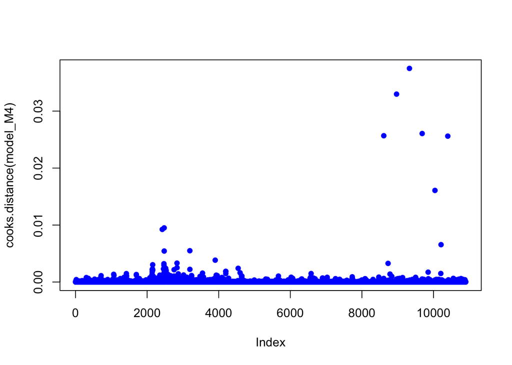

```r
plot(cooks.distance(model_M4), pch = 16, col = "blue")
```

```r
#TODO aus diesem Vektor der class numeric die Ausreißer identifizieren, dann entweder entsprechenden Datensätze löschen oder Umsatz auf einen Max-Wert setzen oder auf Mean setzen....
```